# ACR regeneration: Coral growth rate after filtering for worm damage

Ninah Munk

2024-05-17

## GROWTH

Read in growth rate data and worm information. Combine data frames.

```r
read.csv("/Users/ninahmunk/Desktop/Projects/Acropora_Regeneration-main/Growth/Output/growthrates.csv") -> growth
read.csv("/Users/ninahmunk/Desktop/Projects/Acropora_Regeneration-main/Wound_Closure/Data/worm_damage.csv")-> worm

growth%>%left_join(worm%>%select(coral_id, affected, percent_affected), by = "coral_id") -> growthdata
```

Turn variables into factors

```r
growthdata%>%mutate(genotype = as.factor (genotype),
                    wound = as.factor(wound),
                    temp = as.factor(temp))-> growthdata
```

# FULL MODEL

```r
#full model
full<- lmer(growthrate ~ wound*temp*percent_affected + (1|genotype), data = growthdata)
anova(full)
```

```
## Type III Analysis of Variance Table with Satterthwaite's method
##                              Sum Sq Mean Sq NumDF  DenDF F value    Pr(>F)
## wound                       0.49079 0.24539     2 83.818  1.3848 0.2560362
## temp                        0.26433 0.26433     1 84.352  1.4917 0.2253570
## percent_affected            2.80248 2.80248     1 24.034 15.8151 0.0005575 ***
## wound:temp                  0.76955 0.38477     2 83.660  2.1714 0.1204045
## wound:percent_affected      0.44918 0.22459     2 85.798  1.2674 0.2867764
## temp:percent_affected       0.00957 0.00957     1 86.099  0.0540 0.8168262
## wound:temp:percent_affected 0.06253 0.03127     2 85.159  0.1764 0.8385559
## ---
## Signif. codes:  0 '***' 0.001 '**' 0.01 '*' 0.05 '.' 0.1 ' ' 1
```

```r
#reduced model
reduced<- lmer(growthrate ~ wound*temp+wound*percent_affected + (1|genotype), data = growthdata)
anova(reduced)
```

```
## Type III Analysis of Variance Table with Satterthwaite's method
##                        Sum Sq Mean Sq NumDF  DenDF F value    Pr(>F)
## wound                  0.5108  0.2554     2 86.933  1.4820 0.2328702
## temp                   0.3450  0.3450     1 86.031  2.0017 0.1607347
## percent_affected       3.4977  3.4977     1 23.550 20.2939 0.0001522 ***
## wound:temp             1.0223  0.5111     2 86.679  2.9656 0.0567800 .
## wound:percent_affected 0.4757  0.2378     2 88.185  1.3799 0.2569831
## ---
## Signif. codes:  0 '***' 0.001 '**' 0.01 '*' 0.05 '.' 0.1 ' ' 1
```

# FILTERING DATA TO REMOVE WORM EFFECT

Here I filter the data to use only the corals that had low worm damage. I systematically filtered the data by lowering the threshold for worm damage until it was not significant in the full model. This threshold is <= 10% worm damage. The remaining sample size is N = 71

```r
growthdata.filtered = subset(growthdata, percent_affected <= 10)
```

# FULL MODEL WITH FILTERED DATA

Here I am running the models again with filtered data. The three way interaction in the full model has a p-value of 0.37 which is moderately unsignificant? I think I should use the full model because the three way interaction is not highly non-significant aka p<0.5. In this model the interaction of wound and temperature is significant, p = 0.03540. (do not interpret temp*)

```r
#full model, percent affected is no longer significant
full.filtered<- lmer(growthrate ~ wound*temp*percent_affected + (1|genotype), data = growthdata.filtered)
anova(full.filtered)
```

```
## Type III Analysis of Variance Table with Satterthwaite's method
##                              Sum Sq Mean Sq NumDF  DenDF F value  Pr(>F)
## wound                       0.50094 0.25047     2 56.580  1.5579 0.21947
## temp                        0.67264 0.67264     1 58.461  4.1839 0.04532 *
## percent_affected            0.27883 0.27883     1 56.686  1.7344 0.19315
## wound:temp                  1.13945 0.56973     2 57.266  3.5438 0.03540 *
## wound:percent_affected      0.52020 0.26010     2 57.815  1.6178 0.20717
## temp:percent_affected       0.63420 0.63420     1 58.997  3.9448 0.05167 .
## wound:temp:percent_affected 0.32159 0.16080     2 58.527  1.0002 0.37402
## ---
## Signif. codes:  0 '***' 0.001 '**' 0.01 '*' 0.05 '.' 0.1 ' ' 1
```

```r
reduced.filtered<- lmer(growthrate ~ wound*temp + temp*percent_affected + (1|genotype), data = growthdata.filtered)
anova(reduced.filtered)
```

```
## Type III Analysis of Variance Table with Satterthwaite's method
##                        Sum Sq Mean Sq NumDF  DenDF F value  Pr(>F)
## wound                 0.17998 0.08999     2 60.077  0.5468 0.58164
## temp                  0.55851 0.55851     1 62.426  3.3938 0.07019 .
## percent_affected      0.11419 0.11419     1 58.586  0.6939 0.40823
## wound:temp            0.81856 0.40928     2 60.396  2.4870 0.09164 .
## temp:percent_affected 0.46781 0.46781     1 63.000  2.8426 0.09674 .
## ---
## Signif. codes:  0 '***' 0.001 '**' 0.01 '*' 0.05 '.' 0.1 ' ' 1
```

# MAKE PAIRWISE COMPARISONS

```r
emmeans <- emmeans(full.filtered, ~ wound*temp*percent_affected)
# Display the EMMs
print(emmeans)
```

```
##  wound temp percent_affected emmean    SE   df lower.CL upper.CL
##  0     A                2.89   1.75 0.129 37.9     1.49     2.01
##  1     A                2.89   1.44 0.123 37.8     1.19     1.69
##  2     A                2.89   1.77 0.130 37.6     1.51     2.04
##  0     H                2.89   1.48 0.120 32.4     1.24     1.73
##  1     H                2.89   1.66 0.129 36.6     1.40     1.92
##  2     H                2.89   1.56 0.125 35.4     1.31     1.81
##
## Degrees-of-freedom method: kenward-roger
## Confidence level used: 0.95
```

```r
# Pairwise comparisons for the levels within each predictor
pairwise_results <- pairs(emmeans)
# Display the pairwise comparisons
print(pairwise_results)
```

```
##  contrast
##  wound0 A percent_affected2.88732394366197 - wound1 A percent_affected2.88732394366197
##  wound0 A percent_affected2.88732394366197 - wound2 A percent_affected2.88732394366197
##  wound0 A percent_affected2.88732394366197 - wound0 H percent_affected2.88732394366197
##  wound0 A percent_affected2.88732394366197 - wound1 H percent_affected2.88732394366197
##  wound0 A percent_affected2.88732394366197 - wound2 H percent_affected2.88732394366197
##  wound1 A percent_affected2.88732394366197 - wound2 A percent_affected2.88732394366197
##  wound1 A percent_affected2.88732394366197 - wound0 H percent_affected2.88732394366197
##  wound1 A percent_affected2.88732394366197 - wound1 H percent_affected2.88732394366197
##  wound1 A percent_affected2.88732394366197 - wound2 H percent_affected2.88732394366197
##  wound2 A percent_affected2.88732394366197 - wound0 H percent_affected2.88732394366197
##  wound2 A percent_affected2.88732394366197 - wound1 H percent_affected2.88732394366197
##  wound2 A percent_affected2.88732394366197 - wound2 H percent_affected2.88732394366197
##  wound0 H percent_affected2.88732394366197 - wound1 H percent_affected2.88732394366197
##  wound0 H percent_affected2.88732394366197 - wound2 H percent_affected2.88732394366197
##  wound1 H percent_affected2.88732394366197 - wound2 H percent_affected2.88732394366197
##  estimate    SE   df t.ratio p.value
##    0.3131 0.169 56.0   1.848  0.4442
##   -0.0218 0.175 56.4  -0.125  1.0000
##    0.2706 0.167 55.5   1.622  0.5876
##    0.0909 0.173 55.5   0.525  0.9949
##    0.1910 0.170 55.1   1.125  0.8690
##   -0.3350 0.170 56.5  -1.971  0.3713
##   -0.0425 0.162 55.8  -0.263  0.9998
##   -0.2223 0.168 55.9  -1.319  0.7732
##   -0.1221 0.166 56.3  -0.735  0.9767
##    0.2924 0.167 55.7   1.751  0.5047
##    0.1127 0.173 55.7   0.652  0.9863
##    0.2129 0.171 56.3   1.243  0.8139
##   -0.1797 0.166 55.2  -1.085  0.8854
##   -0.0796 0.163 55.7  -0.487  0.9965
##    0.1002 0.170 55.9   0.589  0.9913
##
## Degrees-of-freedom method: kenward-roger
## P value adjustment: tukey method for comparing a family of 6 estimates
```

# VISUALIZE GROWTH BASED ON RESULTS OF FULL MODEL WITH FILTERED DATA

In the second figure there is a growth reduction at warmer temp for control corals. Similar pattern for abrased corals. Overall growth lowered for fragmented corals but in an opposite pattern with respect to temperature.

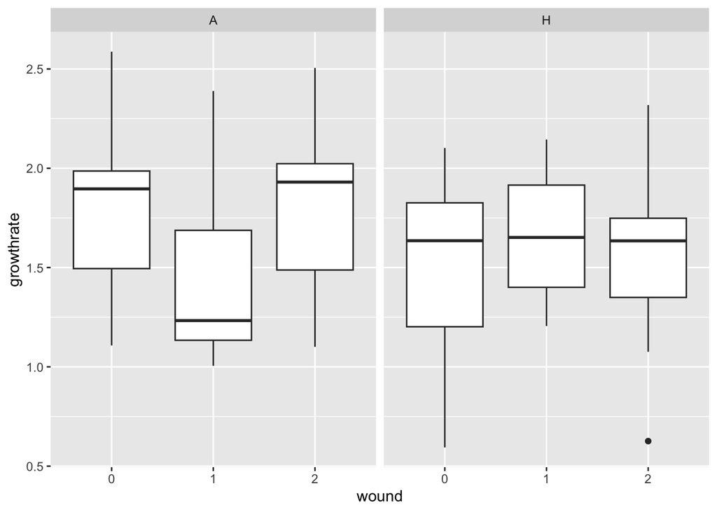

```r
ggplot(data = growthdata.filtered, aes(x = wound, growthrate))+ geom_boxplot()+facet_wrap(~temp)
```

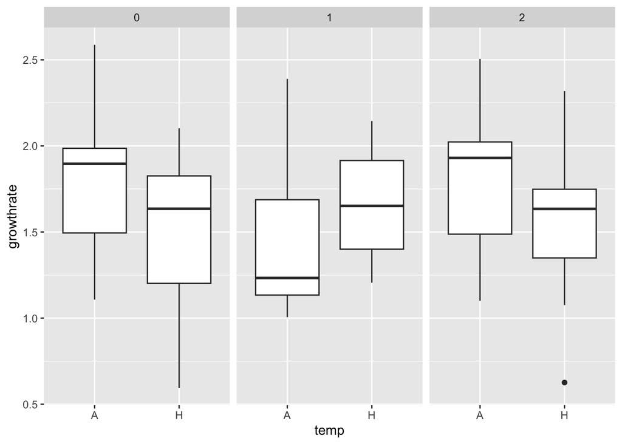

```r
ggplot(data = growthdata.filtered, aes(x = temp, growthrate))+ geom_boxplot()+facet_wrap(~wound)
```

Run models within each wound treatment. There is a significant difference of growth rate between ambient and elevated control corals, where growth is reduced for unwounded corals at warmer temperature.

```r
anova(control<- lmer(growthrate ~ temp*percent_affected + (1|genotype), data = growthdata.filtered%>%filter(wound == "0"))) #N = 25
```

```
## Type III Analysis of Variance Table with Satterthwaite's method
##                        Sum Sq Mean Sq NumDF  DenDF F value  Pr(>F)
## temp                  0.98513 0.98513     1 20.363  6.7447 0.01708 *
## percent_affected      0.02362 0.02362     1 20.716  0.1617 0.69168
## temp:percent_affected 0.43247 0.43247     1 19.744  2.9609 0.10093
## ---
## Signif. codes:  0 '***' 0.001 '**' 0.01 '*' 0.05 '.' 0.1 ' ' 1
```

```r
anova(fragment<- lmer(growthrate ~ temp*percent_affected + (1|genotype), data = growthdata.filtered%>%filter(wound == "1"))) # N = 23
```

```
## boundary (singular) fit: see help('isSingular')
```

```
## Type III Analysis of Variance Table with Satterthwaite's method
##                         Sum Sq  Mean Sq NumDF DenDF F value Pr(>F)
## temp                  0.180706 0.180706     1    19  1.1178 0.3036
## percent_affected      0.052619 0.052619     1    19  0.3255 0.5750
## temp:percent_affected 0.000619 0.000619     1    19  0.0038 0.9513
```

```r
anova(abrasion<- lmer(growthrate ~ temp*percent_affected + (1|genotype), data = growthdata.filtered%>%filter(wound == "2"))) # N = 23
```

```
## Type III Analysis of Variance Table with Satterthwaite's method
##                        Sum Sq Mean Sq NumDF  DenDF F value Pr(>F)
## temp                  0.51465 0.51465     1 18.585  2.9495 0.1025
## percent_affected      0.51496 0.51496     1 18.834  2.9513 0.1022
## temp:percent_affected 0.24972 0.24972     1 18.198  1.4312 0.2469
```

# BREAK DOWN OF SAMPLE SIZE WITHIN TREATMENTS

First I make a histogram to look at how genotype (i.e., parental colony) is represented by worm damage. The most heavily affected corals were from parental colonies: 68, 69, and 70. Genotype was originally represented by an n of 3 within each treatment (genotypeXwoundXtemp, n = 3), but now there are several cases n = 1. Next I check the sample sizes of the woundxtemperature treatments disregarding genotype. These sample sizes range between n = 11-13.

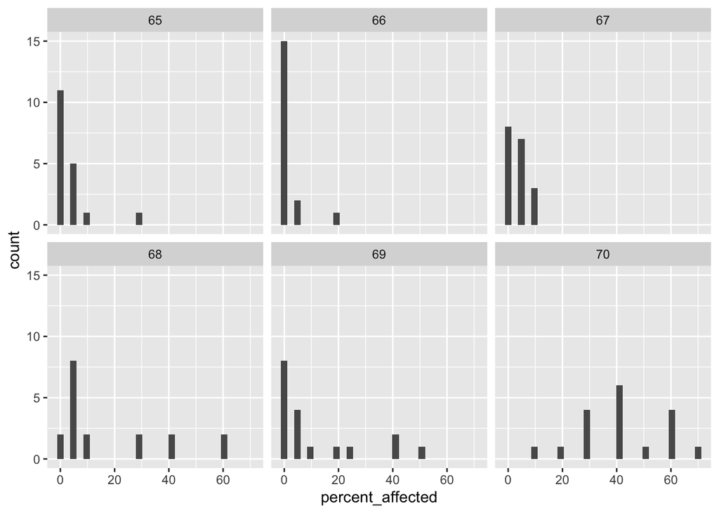

```r
ggplot(data = worm, aes(x = percent_affected))+geom_histogram()+facet_wrap(~genotype)
```

```r
summarySE(data = growthdata.filtered, measurevar = "growthrate", groupvars = c("wound", "temp", "genotype"),
          na.rm = FALSE, conf.interval = 0.95, .drop = TRUE)
```

```
##    wound temp genotype N growthrate         sd         se        ci
## 1      0    A       65 3   1.933019 0.66994425 0.38679249 1.6642338
## 2      0    A       66 3   1.633389 0.45590318 0.26321583 1.1325263
## 3      0    A       67 3   2.027750 0.07105983 0.04102641 0.1765224
## 4      0    A       68 1   1.278185         NA         NA       NaN
## 5      0    A       69 2   1.693037 0.17843160 0.12617019 1.6031443
## 6      0    H       65 3   1.589039 0.35833495 0.20688478 0.8901534
## 7      0    H       66 3   1.010688 0.36859124 0.21280625 0.9156314
## 8      0    H       67 3   1.762085 0.20531976 0.11854142 0.5100426
## 9      0    H       68 2   1.964122 0.19546838 0.13821702 1.7562138
## 10     0    H       69 2   1.313504 0.28941806 0.20464947 2.6003181
## 11     1    A       65 2   1.244077 0.19746600 0.13962955 1.7741616
## 12     1    A       66 3   1.528598 0.32779383 0.18925186 0.8142850
## 13     1    A       67 3   1.414264 0.56066591 0.32370061 1.3927713
## 14     1    A       68 1   1.005428         NA         NA       NaN
```

[output cut: 17 more lines]

```r
print(growthdata.filtered %>% group_by(wound, temp) %>% reframe(samp.size=n()))
```

```
## # A tibble: 6 × 3
##   wound temp  samp.size
##   <fct> <fct>     <int>
## 1 0     A            12
## 2 0     H            13
## 3 1     A            12
## 4 1     H            11
## 5 2     A            11
## 6 2     H            12
```

# HOW MANY OF THE REMAINING CORALS DO I ALSO HAVE REGENERATION DATA FOR?

Out of the 71 corals I have growth data on, I have regeneration data for 14 of those. Within each timepoint/wound/temp treatment there is a sample size of 3-4. I will have to check how worm damage acts as a covaiate in the regeneration data.

```r
read.csv("/Users/ninahmunk/Desktop/Projects/Acropora_Regeneration-main/Wound_Closure/Data/all.wounds.csv") -> regen

growthdata.filtered%>%left_join(regen, by = "coral_id")%>%drop_na() -> growthregen

print(growthregen %>% group_by(coral_id) %>% reframe(samp.size=n()))
```

```
## # A tibble: 14 × 2
##    coral_id samp.size
##       <int>     <int>
##  1       10         4
##  2       13         4
##  3       38         4
##  4       39         4
##  5       48         4
##  6       65         4
##  7       66         4
##  8       72         4
##  9       79         4
## 10       80         4
## 11       82         4
## 12       88         4
## 13      102         4
## 14      105         4
```

```r
print(growthregen %>% group_by(time_point, wound, temp) %>% reframe(samp.size=n()))
```

```
## # A tibble: 16 × 4
##    time_point wound temp  samp.size
##    <chr>      <fct> <fct>     <int>
##  1 24hr       1     A             3
##  2 24hr       1     H             4
##  3 24hr       2     A             3
##  4 24hr       2     H             4
##  5 day10      1     A             3
##  6 day10      1     H             4
##  7 day10      2     A             3
##  8 day10      2     H             4
##  9 final      1     A             3
## 10 final      1     H             4
## 11 final      2     A             3
## 12 final      2     H             4
## 13 initial    1     A             3
## 14 initial    1     H             4
## 15 initial    2     A             3
## 16 initial    2     H             4
```